# Bærekraftig bestand

## Dette må du kunne

I dette eksempelet bruker vi arrays, løkker og plot funksjonalitet.

## Modell

Den forrige modellen førte til at bestanden vokste raskere og raskere ettersom tiden gikk og vi fikk en eksponensiell vekst. I naturen er det som regel en øvre grense ($M$) for hvor mange individer som kan leve i et område samtidig. Mat- og plassmangel, konkurranse mellom individer, rovdyr og smittsomme sykdommer er alle faktorer som begrenser veksten av en bestand. Tallet $M$ kalles systemets bæreevne og representerer den maksimale størrelsen på en bestand som er bærekraftig over tid. Når veksten er begrenset betyr det at vekstraten $r$ må være avhengig av tiden:

$$y_n = y_{n-1} + r(n-1)y_{n-1}$$

I begynnelsen når det er nok ressurser så vokser bestanden eksponensielt, men med tiden når $y$ går mot $M$ stopper veksten opp og $r$ går mot null. Her er en funksjon med disse egenskapene

$r(n) = R\left(1 - \frac{y_n}{M}\right)$

## Eksempel

La oss gå tilbake til harene fra forrige eksempel. Fortsatt representerer $y$ antall harer som bor på en øy. Til å begynne med er fødselsraten $7\%$ per måned, dødsraten $2\%$ og vi starter med en bestand på 100 harer. Vi antar at for at bestanden skal være bærekraftig kan det maksimalt være 500 harer på øya. Hvor mange harer bor det på øya etter 5 år?

Vi har altså $b = \frac{7\%}{100\%}$ og $d = \frac{2\%}{100\%}$ som gir initiell vekstrate $R = b - d = 0.05$. Videre vet vi at vi starter med $y_0 = 100$ og at bæreevnen $M = 500$. Nå kan vi sette dette inn i den nye formelen vår og regne ut

$$y_1 = y_{0} + Ry_{0}\left(1 - \frac{y_0}{M}\right) = 100 + 0.05\cdot100\left(1 - \frac{100}{500}\right) = 104$$$$\qquad\vdots\qquad\vdots\qquad$$

Slik kan vi fortsette å regne ut utviklingen av harebestanden. Her er tidssteget mellom $y_0$ og $y_1$ en måned så vi må regne ut 60 tidssteg for å finne ut hvor mange harer som bor på øya etter fem år. I stedet for å gjøre dette for hånd kan vi skrive et tilsvarende program som i forrige eksempel

```python
import numpy as np
y0 = 100       # antall individer når vi starter
M = 500        # bæreevne
R = 0.05       # vekstrate når vi starter
N = 12*5      # antall tidsintervaller (gjør om dette til dager eller år konkret eksempel!)
index_set = range(N+1)
y = np.zeros(len(index_set))

# Regn ut løsning for hvert intervall
y[0] = y0
for n in index_set[1:]:
    y[n] = y[n-1] + R*y[n-1]*(1 - y[n-1]/float(M))
print y
```

```
[ 100.          104.          108.1184      112.35536116  116.7107565
  121.18415425  125.77480204  130.48161206  135.30314756  140.23761076
  145.28283255  150.43626404  155.69497028  161.05562642  166.51451626
  172.06753366  177.71018673  183.43760502  189.24454978  195.12542731
  201.07430543  207.08493307  213.15076278  219.26497615  225.42051198
  231.61009686  237.826278    244.06145805  250.30793142  256.55792194
  262.80362131  269.03722804  275.25098643  281.4372252   287.58839529
  293.69710654  299.75616283  305.75859525  311.69769316  317.56703263
  323.36050224  329.07232591  334.69708263  340.22972305  345.66558276
  351.00039239  356.23028446  361.35179713  366.36187486  371.25786626
  376.03751925  380.69897363  385.24075145  389.66174537  393.96120506
  398.1387222   402.1942141   406.12790622  409.94031391  413.63222351
  417.20467305]
```

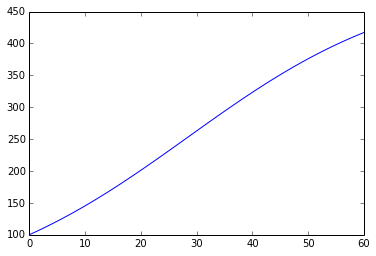

```python
%matplotlib inline
import matplotlib.pyplot as pl
pl.plot(index_set, y)
```

## Oppgaver

### Oppg 1

a) Hva skjer med bestanden etter 100 år?

b) Hva skjer hvis vi endrer vekstraten til $r = 1.5$. Hva betyr egentlig dette?

c) Diskuter hvor realistisk denne modellen er.

### Oppg 2

Finne på et eksempel til :)